# AllLife Bank Customer Segmentation

## Description

```
AllLife Bank wants to focus on its credit card customer base in the next financial year. They have been advised by their marketing research team, that the penetration in the market can be improved. Based on this input, the Marketing team proposes to run personalized campaigns to target new customers as well as upsell to existing customers. Another insight from the market research was that the customers perceive the support services of the back poorly. Based on this, the Operations team wants to upgrade the service delivery model, to ensure that customer queries are resolved faster. Head of Marketing and Head of Delivery both decide to reach out to the Data Science team for help.
```

### Objective

```
To identify different segments in the existing customer, based on their spending patterns as well as past interaction with the bank, using clustering algorithms, and provide recommendations to the bank on how to better market to and service these customers.
```

### Data Description

```
The data provided is of various customers of a bank and their financial attributes like credit limit, the total number of credit cards the customer has, and different channels through which customers have contacted the bank for any queries (including visiting the bank, online and through a call center).
```

#### Data Dictionary

```
Sl_No: Primary key of the records
Customer Key: Customer identification number
Average Credit Limit: Average credit limit of each customer for all credit cards
Total credit cards: Total number of credit cards possessed by the customer
Total visits bank: Total number of visits that customer made (yearly) personally to the bank
Total visits online: Total number of visits or online logins made by the customer (yearly)
Total calls made: Total number of calls made by the customer to the bank or its customer service department (yearly)
```

### Importing necessary libraries

```python
# This will help in making the Python code more structured automatically (good coding practice)
%load_ext nb_black

# Libraries to help with reading and manipulating data
import numpy as np
import pandas as pd

# Libraries to help with data visualization
import matplotlib.pyplot as plt
import seaborn as sns

# To visualize the elbow curve and silhouette scores
from yellowbrick.cluster import KElbowVisualizer, SilhouetteVisualizer

# Removes the limit for the number of displayed columns
pd.set_option("display.max_columns", None)
# Sets the limit for the number of displayed rows
pd.set_option("display.max_rows", 200)

# To scale the data using z-score
from sklearn.preprocessing import StandardScaler

# To compute distances
from scipy.spatial.distance import pdist
from scipy.spatial.distance import cdist

# To perform k-means clustering and compute silhouette scores
from sklearn.cluster import KMeans
from sklearn.metrics import silhouette_score

# To perform hierarchical clustering, compute cophenetic correlation, and create dendrograms
from sklearn.cluster import AgglomerativeClustering
from scipy.cluster.hierarchy import dendrogram, linkage, cophenet

# To perform PCA
from sklearn.decomposition import PCA


# Removes the limit for the number of displayed columns
pd.set_option("display.max_columns", None)
# Sets the limit for the number of displayed rows
pd.set_option("display.max_rows", 200)
```

### Reading data from dataset

```python
dataCC = pd.read_excel("Credit Card Customer Data.xlsx")
```

```python
# Creating a copy of Data
data = dataCC.copy()
```

```python
data.shape
```

```
(660, 7)
```

- There are 660 rows and 7 column features

```python
# Inspecting Head and Tail of records
```

```python
data.head()
```

|  | Sl_No | Customer Key | Avg_Credit_Limit | Total_Credit_Cards | Total_visits_bank | Total_visits_online | Total_calls_made |
| --- | --- | --- | --- | --- | --- | --- | --- |
| 0 | 1 | 87073 | 100000 | 2 | 1 | 1 | 0 |
| 1 | 2 | 38414 | 50000 | 3 | 0 | 10 | 9 |
| 2 | 3 | 17341 | 50000 | 7 | 1 | 3 | 4 |
| 3 | 4 | 40496 | 30000 | 5 | 1 | 1 | 4 |
| 4 | 5 | 47437 | 100000 | 6 | 0 | 12 | 3 |

```python
data.tail()
```

|  | Sl_No | Customer Key | Avg_Credit_Limit | Total_Credit_Cards | Total_visits_bank | Total_visits_online | Total_calls_made |
| --- | --- | --- | --- | --- | --- | --- | --- |
| 655 | 656 | 51108 | 99000 | 10 | 1 | 10 | 0 |
| 656 | 657 | 60732 | 84000 | 10 | 1 | 13 | 2 |
| 657 | 658 | 53834 | 145000 | 8 | 1 | 9 | 1 |
| 658 | 659 | 80655 | 172000 | 10 | 1 | 15 | 0 |
| 659 | 660 | 80150 | 167000 | 9 | 0 | 12 | 2 |

```python
# Inspecting the properties of
data.info()
```

```
<class 'pandas.core.frame.DataFrame'>
RangeIndex: 660 entries, 0 to 659
Data columns (total 7 columns):
 #   Column               Non-Null Count  Dtype
---  ------               --------------  -----
 0   Sl_No                660 non-null    int64
 1   Customer Key         660 non-null    int64
 2   Avg_Credit_Limit     660 non-null    int64
 3   Total_Credit_Cards   660 non-null    int64
 4   Total_visits_bank    660 non-null    int64
 5   Total_visits_online  660 non-null    int64
 6   Total_calls_made     660 non-null    int64
dtypes: int64(7)
memory usage: 36.2 KB
```

- All records re of datatype integer
- Sl_No field to identify the customers, it will not be contributing to model.So it can be dropped.
- Customer Key requires inspection for duplicate values i.e. a customer can have multiple credit cards or visits or calls made.

```python
data.isnull().sum()
```

```
Sl_No                  0
Customer Key           0
Avg_Credit_Limit       0
Total_Credit_Cards     0
Total_visits_bank      0
Total_visits_online    0
Total_calls_made       0
dtype: int64
```

- There is no missing records.

```python
# let's check for duplicate observations
data.duplicated().sum()
```

```
0
```

- There is no duplicate records

**Inspecting the summary of data**

```python
data.describe().T
```

|  | count | mean | std | min | 25% | 50% | 75% | max |
| --- | --- | --- | --- | --- | --- | --- | --- | --- |
| Sl_No | 660.0 | 330.500000 | 190.669872 | 1.0 | 165.75 | 330.5 | 495.25 | 660.0 |
| Customer Key | 660.0 | 55141.443939 | 25627.772200 | 11265.0 | 33825.25 | 53874.5 | 77202.50 | 99843.0 |
| Avg_Credit_Limit | 660.0 | 34574.242424 | 37625.487804 | 3000.0 | 10000.00 | 18000.0 | 48000.00 | 200000.0 |
| Total_Credit_Cards | 660.0 | 4.706061 | 2.167835 | 1.0 | 3.00 | 5.0 | 6.00 | 10.0 |
| Total_visits_bank | 660.0 | 2.403030 | 1.631813 | 0.0 | 1.00 | 2.0 | 4.00 | 5.0 |
| Total_visits_online | 660.0 | 2.606061 | 2.935724 | 0.0 | 1.00 | 2.0 | 4.00 | 15.0 |
| Total_calls_made | 660.0 | 3.583333 | 2.865317 | 0.0 | 1.00 | 3.0 | 5.00 | 10.0 |

**Observations**

- Sl_No and Customer Key is a customer identification key here percentile, mean, deviation min and max value is not relevent.
- Average credit limit is right skewed with maximum value of 200000. This can bea outlier.
- On average people has 5 credit cards close to mean value Also, some customer has 10 credit cards.
- Total_Visits_bank: Average peole makes close to 2 visits. Some customers has not made any visits but some has made upto 5 visits.
- Total_Visits_Online: Online vistis data os sligtly right skewed. Some customers are not using online features where as some customer are using online features up to 15 times.
- Total_calls_made: Total calls is slightly right skewed with close to 3 calls on average. But some customers are making up to 10 calls.

```python
data["Customer Key"].value_counts()
```

```
47437    2
37252    2
97935    2
96929    2
50706    2
        ..
66706    1
72339    1
69965    1
85645    1
71681    1
Name: Customer Key, Length: 655, dtype: int64
```

- There is duplicate customer_key value that means those customers are using multiple feature. Therefore, We can keep this columns.

```python
# Fixing column names
data.columns = [col.replace(" ", "_") for col in data.columns]
```

```python
# Dropping Sl_No , which is primary key for records
data.drop(["Sl_No"], axis=1, inplace=True)
```

```python
data.info()
```

```
<class 'pandas.core.frame.DataFrame'>
RangeIndex: 660 entries, 0 to 659
Data columns (total 6 columns):
 #   Column               Non-Null Count  Dtype
---  ------               --------------  -----
 0   Customer_Key         660 non-null    int64
 1   Avg_Credit_Limit     660 non-null    int64
 2   Total_Credit_Cards   660 non-null    int64
 3   Total_visits_bank    660 non-null    int64
 4   Total_visits_online  660 non-null    int64
 5   Total_calls_made     660 non-null    int64
dtypes: int64(6)
memory usage: 31.1 KB
```

- All columns names are fixed.
- Sl_No column is removed. Now we have total of 6 columns.

## EDA

### Univariate Analysis

```python
# function to plot a boxplot and a histogram along the same scale.


def histogram_boxplot(data, feature, figsize=(12, 7), kde=False, bins=None):
    """
    Boxplot and histogram combined

    data: dataframe
    feature: dataframe column
    figsize: size of figure (default (12,7))
    kde: whether to the show density curve (default False)
    bins: number of bins for histogram (default None)
    """
    f2, (ax_box2, ax_hist2) = plt.subplots(
        nrows=2,  # Number of rows of the subplot grid= 2
        sharex=True,  # x-axis will be shared among all subplots
        gridspec_kw={"height_ratios": (0.25, 0.75)},
        figsize=figsize,
    )  # creating the 2 subplots
    sns.boxplot(
        data=data, x=feature, ax=ax_box2, showmeans=True, color="violet"
    )  # boxplot will be created and a star will indicate the mean value of the column
    sns.histplot(
        data=data, x=feature, kde=kde, ax=ax_hist2, bins=bins, palette="winter"
    ) if bins else sns.histplot(
        data=data, x=feature, kde=kde, ax=ax_hist2
    )  # For histogram
    ax_hist2.axvline(
        data[feature].mean(), color="green", linestyle="--"
    )  # Add mean to the histogram
    ax_hist2.axvline(
        data[feature].median(), color="black", linestyle="-"
    )  # Add median to the histogram
```

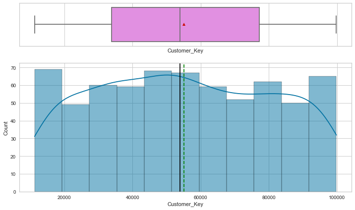

```python
# Selecting numerical columns for Histogram and Box plots
num_cols = data.select_dtypes(include=np.number).columns.tolist()
histogram_boxplot(data, "Customer_Key", kde=True)
```

- Customer_Key is is spread beteween 10000 to 100000.
- Since its key to identify the customer , we don't get much information from it.

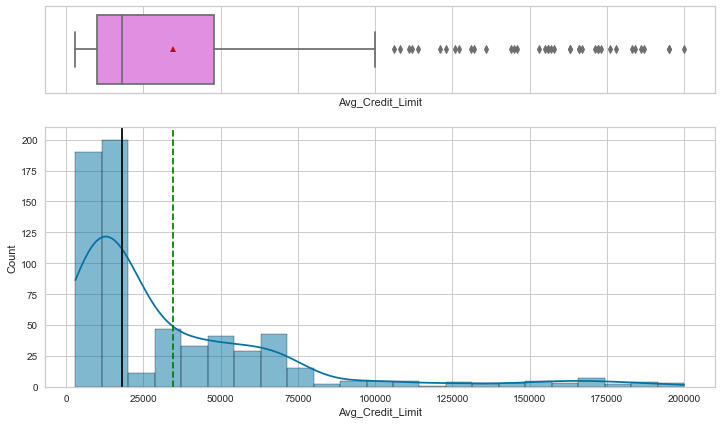

```python
# selecting numerical columns
histogram_boxplot(data, "Avg_Credit_Limit", kde=True)
```

- Average credit limit is right skewed with lots of outliers
- Since, outlier credit limit values are important we'll not treat it.

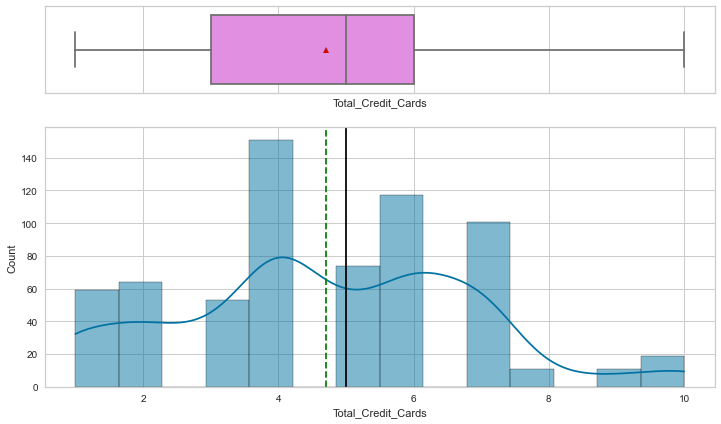

```python
histogram_boxplot(data, "Total_Credit_Cards", kde=True)
```

- Range of credit cards from 1 to 10.
- Large group of customes has 4 credit cards and some of the customers has 10 credit cards.

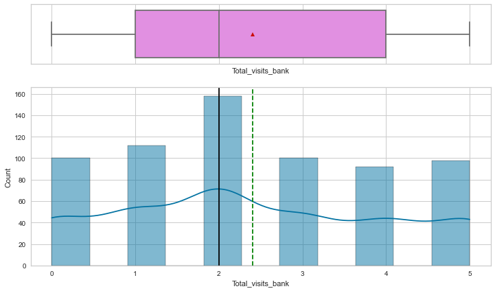

```python
histogram_boxplot(data, "Total_visits_bank", kde=True)
```

- On average there is 2 visits per year
- While many of the customers haven't visted the bank at all where as some of the customers visited the bank 4 or 5 times, which needs to investigated.

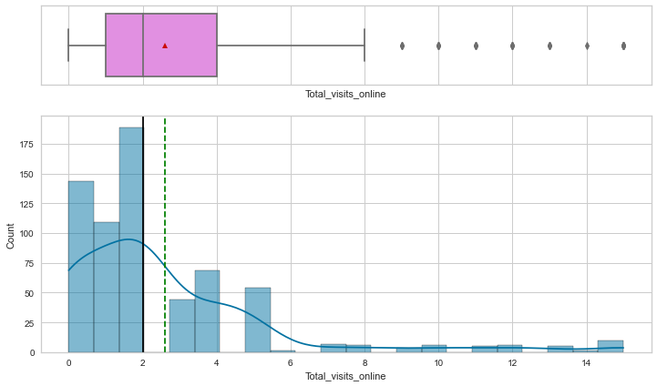

```python
histogram_boxplot(data, "Total_visits_online", kde=True)
```

- Total online visits is right skewed. Large number of customers using online features less than 2 times. customers needs to be educated for online feature.
- Very small number of customers are using onine features frequently.

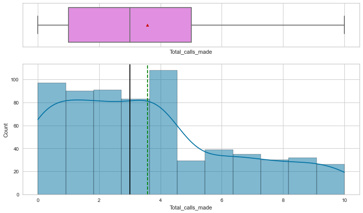

```python
histogram_boxplot(data, "Total_calls_made", kde=True)
```

- Total call made is right skewed.Some customers has made more than 6 calls which needs to be investigated.

```python
# function to create labeled barplots


def labeled_barplot(data, feature, perc=False, n=None):
    """
    Barplot with percentage at the top

    data: dataframe
    feature: dataframe column
    perc: whether to display percentages instead of count (default is False)
    n: displays the top n category levels (default is None, i.e., display all levels)
    """

    total = len(data[feature])  # length of the column
    count = data[feature].nunique()
    if n is None:
        plt.figure(figsize=(count + 1, 5))
    else:
        plt.figure(figsize=(n + 1, 5))

    plt.xticks(rotation=90, fontsize=15)
    ax = sns.countplot(
        data=data,
        x=feature,
        palette="Paired",
        order=data[feature].value_counts().index[:n].sort_values(),
    )

    for p in ax.patches:
        if perc == True:
            label = "{:.1f}%".format(
                100 * p.get_height() / total
            )  # percentage of each class of the category
        else:
            label = p.get_height()  # count of each level of the category

        x = p.get_x() + p.get_width() / 2  # width of the plot
        y = p.get_height()  # height of the plot

        ax.annotate(
            label,
            (x, y),
            ha="center",
            va="center",
            size=12,
            xytext=(0, 5),
            textcoords="offset points",
        )  # annotate the percentage

    plt.show()  # show the plot
```

### Bivariate Analysis

**Inspecting the coorelations**

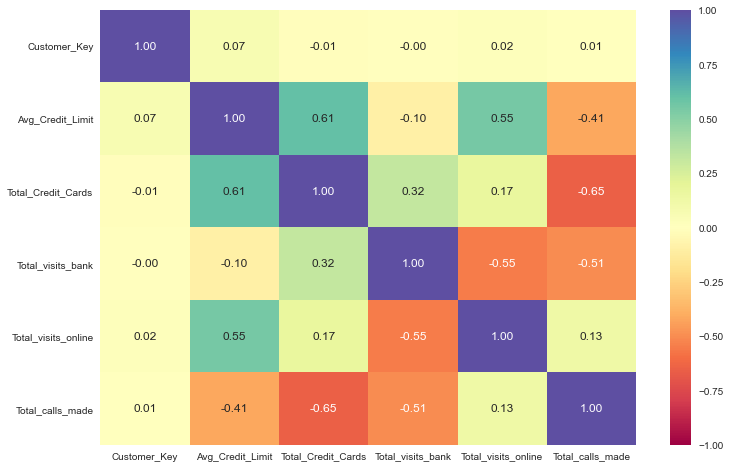

```python
plt.figure(figsize=(12, 8))
sns.heatmap(data.corr(), annot=True, vmin=-1, vmax=1, fmt=".2f", cmap="Spectral")
plt.show()
```

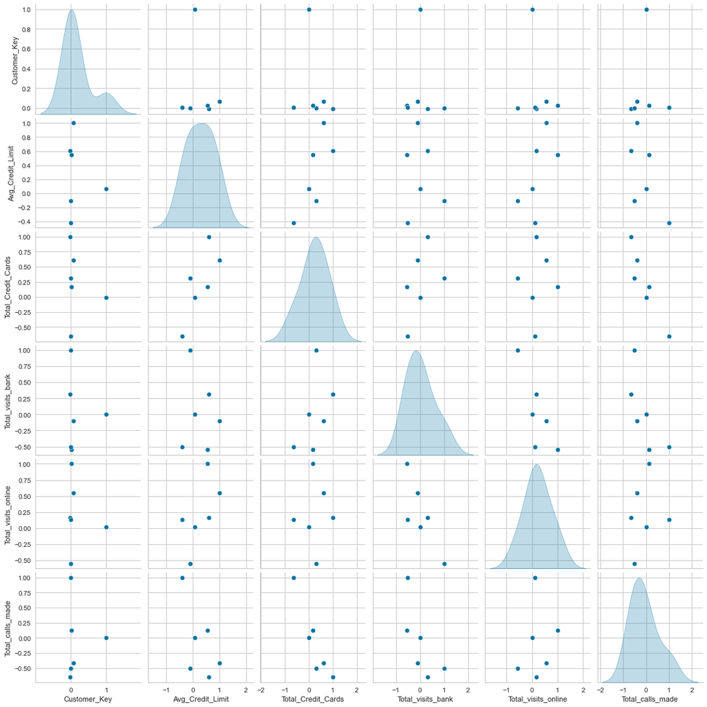

```python
sns.pairplot(data.corr(), diag_kind="kde")
plt.show()
```

**Scaling the data to cluster the records.**

```python
sc = StandardScaler()
scaled_cls_data = pd.DataFrame(
    sc.fit_transform(data.drop(["Customer_Key"], axis=1)),
    columns=data.drop(["Customer_Key"], axis=1).columns,
)
scaled_cls_data.head()
```

|  | Avg_Credit_Limit | Total_Credit_Cards | Total_visits_bank | Total_visits_online | Total_calls_made |
| --- | --- | --- | --- | --- | --- |
| 0 | 1.740187 | -1.249225 | -0.860451 | -0.547490 | -1.251537 |
| 1 | 0.410293 | -0.787585 | -1.473731 | 2.520519 | 1.891859 |
| 2 | 0.410293 | 1.058973 | -0.860451 | 0.134290 | 0.145528 |
| 3 | -0.121665 | 0.135694 | -0.860451 | -0.547490 | 0.145528 |
| 4 | 1.740187 | 0.597334 | -1.473731 | 3.202298 | -0.203739 |

## K-means clustering

```
Cluster Number: 1 , Distortion: 2.0069222262503614
Cluster Number: 2 , Distortion: 1.4571553548514269
Cluster Number: 3 , Distortion: 1.1466276549150365
Cluster Number: 4 , Distortion: 1.0463825294774465
Cluster Number: 5 , Distortion: 0.990772333470802
Cluster Number: 6 , Distortion: 0.9427934574350474
Cluster Number: 7 , Distortion: 0.9095041987080354
Cluster Number: 8 , Distortion: 0.8891818736424425
Cluster Number: 9 , Distortion: 0.8616068550962003
Cluster Number: 10 , Distortion: 0.8434165018544575
```

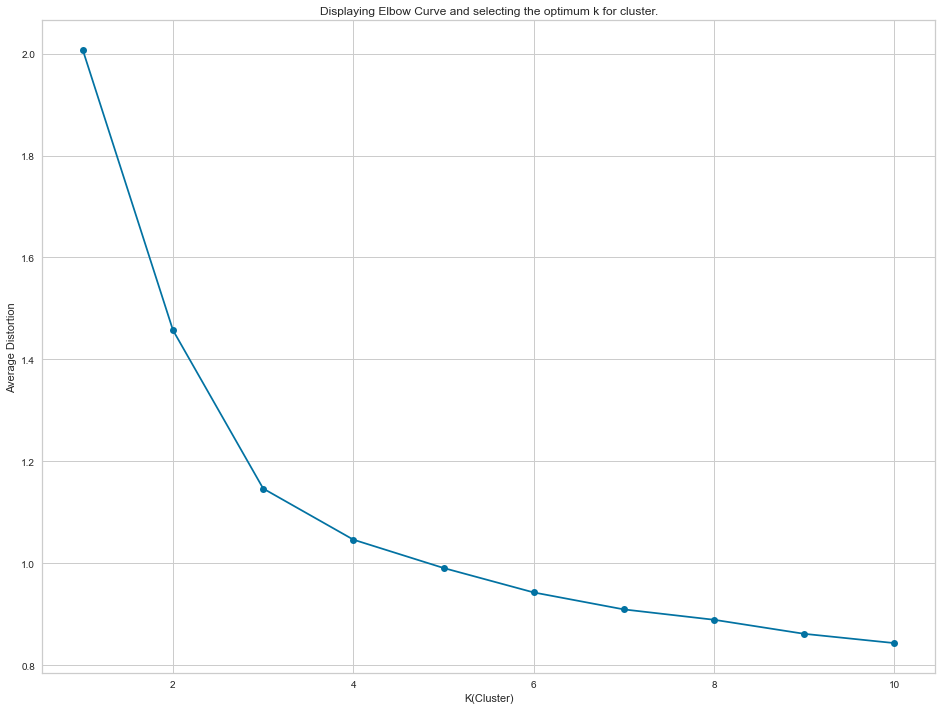

```python
# Plotting the Elbow curve to analyze the number of clusters

clusters = range(1, 11)
meanDistortions = []

for cls in clusters:
    model = KMeans(n_clusters=cls)
    model.fit(scaled_cls_data)
    prediction = model.predict(scaled_cls_data)
    distortion = (
        sum(np.min(cdist(scaled_cls_data, model.cluster_centers_, "euclidean"), axis=1))
        / scaled_cls_data.shape[0]
    )
    meanDistortions.append(distortion)
    print("Cluster Number: {0} , Distortion: {1} ".format(cls, distortion))

plt.figure(figsize=(16, 12))
plt.xlabel("K(Cluster)")
plt.ylabel("Average Distortion")
plt.title("Displaying Elbow Curve and selecting the optimum k for cluster.")
plt.plot(clusters, meanDistortions, "-o")
```

**From above Elbow curve it seems 4 or 5 will be appropriate choice.**

**Now, We'll verify the silhouette score**

```
For cluster 2, Silhouette Score: 0.41842496663230405
For cluster 3, Silhouette Score: 0.5157182558882754
For cluster 4, Silhouette Score: 0.35566706193773706
For cluster 5, Silhouette Score: 0.2723916744639754
For cluster 6, Silhouette Score: 0.2558637700771479
For cluster 7, Silhouette Score: 0.2499242599612321
For cluster 8, Silhouette Score: 0.22705107956839776
For cluster 9, Silhouette Score: 0.22094919286747713
```

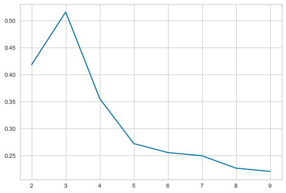

```python
sil_scores = []
cluster_list = list(range(2, 10))
for cls in cluster_list:
    model = KMeans(n_clusters=cls)
    pred = model.fit_predict(scaled_cls_data)
    score = silhouette_score(scaled_cls_data, pred)
    sil_scores.append(score)
    print("For cluster {0}, Silhouette Score: {1}".format(cls, score))
plt.plot(cluster_list, sil_scores)
```

**Cluster 3 has the highest silhoutte score.**

#### We'll find optimal number of clusters with help of silhouette score

```python
def plot_silhouette_visualizer(df, cluster):
    """
    Method to plot silhouette visualizer with given dataframe and cluster number
    """
    visualizer = SilhouetteVisualizer(KMeans(cluster, random_state=1))
    visualizer.fit(df)
    visualizer.show()
```

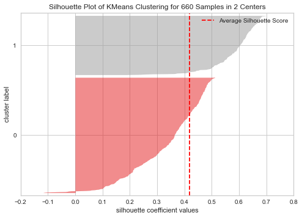

```python
# Plot Silhouetter visualizer for cluster = 2
plot_silhouette_visualizer(scaled_cls_data, 2)
```

- Cluster 0 has negative silhoutte score and both clusters are not unfirmally distributed.

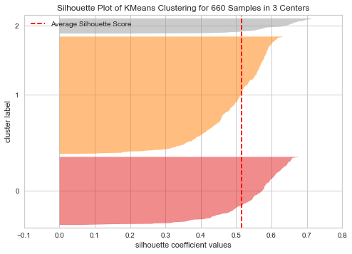

```python
# Plot Silhouetter visualizer for cluster = 3
plot_silhouette_visualizer(scaled_cls_data, 3)
```

- All three Clusters are not uniformally distributed.

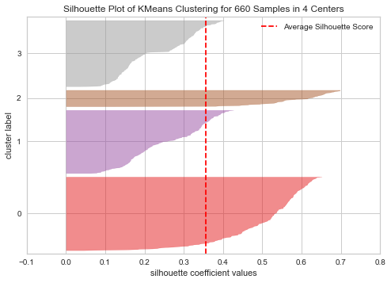

```python
# Plot Silhouetter visualizer for cluster = 4
plot_silhouette_visualizer(scaled_cls_data, 4)
```

- There is no negative silhouette score for any cluster.
- Except for cluster 2 Cluster, all other clusters are uniformally distributed.

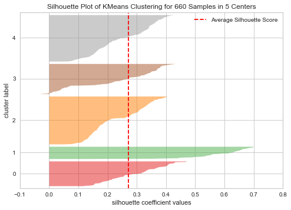

```python
# Plot Silhouetter visualizer for cluster = 5
plot_silhouette_visualizer(scaled_cls_data, 5)
```

**We'll consider 4 as right no. of clusters as the silhouette score is high enough and there is knick at 4 in the elbow curve.**

```python
kmeans = KMeans(n_clusters=4, random_state=1)
kmeans.fit(scaled_cls_data)
```

```
KMeans(n_clusters=4, random_state=1)
```

```python
# Adding kmeans cluster labels to the original dataframe
data["K_means_segments"] = kmeans.labels_
```

```python
cluster_profile = data.groupby("K_means_segments").mean()
```

```python
cluster_profile["count_in_each_segment"] = (
    data.groupby("K_means_segments")["Customer_Key"].count().values
)
```

```python
# let's display cluster profiles
cluster_profile.style.highlight_max(color="lightgreen", axis=0)
```

| K_means_segments | Customer_Key | Avg_Credit_Limit | Total_Credit_Cards | Total_visits_bank | Total_visits_online | Total_calls_made | count_in_each_segment |
| --- | --- | --- | --- | --- | --- | --- | --- |
| 0 | 55714.684211 | 31226.315789 | 5.478947 | 4.515789 | 1.010526 | 1.936842 | 190 |
| 1 | 55257.135747 | 12167.420814 | 2.393665 | 0.927602 | 3.574661 | 6.923077 | 221 |
| 2 | 54071.849246 | 35904.522613 | 5.522613 | 2.477387 | 0.969849 | 2.075377 | 199 |
| 3 | 56708.760000 | 141040.000000 | 8.740000 | 0.600000 | 10.900000 | 1.080000 | 50 |

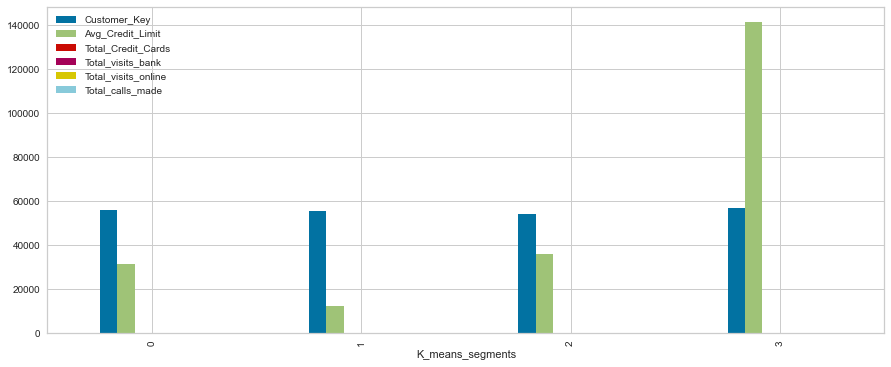

```python
data.groupby("K_means_segments").mean().plot.bar(figsize=(15, 6))
```

- This plot is not giving much details and information for other feature. We'll analyse box plot.

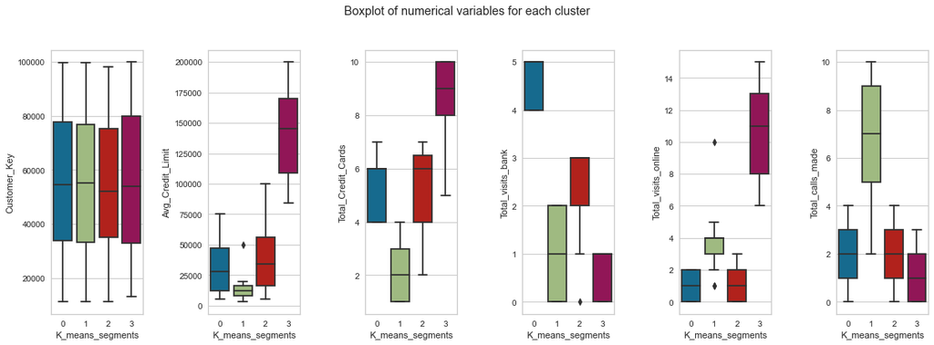

```python
fig, axes = plt.subplots(1, 6, figsize=(16, 6))
fig.suptitle("Boxplot of numerical variables for each cluster")
counter = 0
for ii in range(6):
    sns.boxplot(ax=axes[ii], y=data[num_cols[counter]], x=data["K_means_segments"])
    counter = counter + 1

fig.tight_layout(pad=2.0)
```


## Hierarchical Clustering

```python
# Dropping the K_means_segments from data
data.drop(["K_means_segments"], axis=1, inplace=True)
data.head()
```

|  | Customer_Key | Avg_Credit_Limit | Total_Credit_Cards | Total_visits_bank | Total_visits_online | Total_calls_made |
| --- | --- | --- | --- | --- | --- | --- |
| 0 | 87073 | 100000 | 2 | 1 | 1 | 0 |
| 1 | 38414 | 50000 | 3 | 0 | 10 | 9 |
| 2 | 17341 | 50000 | 7 | 1 | 3 | 4 |
| 3 | 40496 | 30000 | 5 | 1 | 1 | 4 |
| 4 | 47437 | 100000 | 6 | 0 | 12 | 3 |

```python
scaled_cls_data.head()
```

|  | Avg_Credit_Limit | Total_Credit_Cards | Total_visits_bank | Total_visits_online | Total_calls_made |
| --- | --- | --- | --- | --- | --- |
| 0 | 1.740187 | -1.249225 | -0.860451 | -0.547490 | -1.251537 |
| 1 | 0.410293 | -0.787585 | -1.473731 | 2.520519 | 1.891859 |
| 2 | 0.410293 | 1.058973 | -0.860451 | 0.134290 | 0.145528 |
| 3 | -0.121665 | 0.135694 | -0.860451 | -0.547490 | 0.145528 |
| 4 | 1.740187 | 0.597334 | -1.473731 | 3.202298 | -0.203739 |

```python
# List of Distance Metrics
distance_metrics = ["euclidean", "chebyshev", "mahalanobis", "cityblock"]

# List of Linkage Methods
linkage_methods = ["single", "complete", "average", "weighted"]


def get_cluster_metrics(df, dist_metric_list, linkage_list):

    max_coeff = 0
    max_dm_lm = [0, 0]

    for dist in dist_metric_list:
        for link in linkage_list:
            Z = linkage(df, method=link, metric=dist)
            coeff, coph_dist = cophenet(Z, pdist(scaled_cls_data))
            print(
                "Metric: {0}, Linkage: {1}, Cophenet Coefficient: {2}".format(
                    dist.capitalize(), link.capitalize(), coeff
                )
            )
            if max_coeff < coeff:
                max_coeff = coeff
                max_dm_lm[0] = dist
                max_dm_lm[1] = link

    print(
        "\nMaximum cophenet Coefficient Obtained using Metric: {0}, Linkage: {1},\nCophenet Coefficient:{2}".format(
            max_dm_lm[0].capitalize(), max_dm_lm[1].capitalize(), max_coeff
        )
    )


get_cluster_metrics(scaled_cls_data, distance_metrics, linkage_methods)
```

```
Metric: Euclidean, Linkage: Single, Cophenet Coefficient: 0.7391220243806552
Metric: Euclidean, Linkage: Complete, Cophenet Coefficient: 0.8599730607972423
Metric: Euclidean, Linkage: Average, Cophenet Coefficient: 0.8977080867389372
Metric: Euclidean, Linkage: Weighted, Cophenet Coefficient: 0.8861746814895477
Metric: Chebyshev, Linkage: Single, Cophenet Coefficient: 0.7382354769296767
Metric: Chebyshev, Linkage: Complete, Cophenet Coefficient: 0.8533474836336782
Metric: Chebyshev, Linkage: Average, Cophenet Coefficient: 0.8974159511838106
Metric: Chebyshev, Linkage: Weighted, Cophenet Coefficient: 0.8913624010768603
Metric: Mahalanobis, Linkage: Single, Cophenet Coefficient: 0.7058064784553605
Metric: Mahalanobis, Linkage: Complete, Cophenet Coefficient: 0.6663534463875359
Metric: Mahalanobis, Linkage: Average, Cophenet Coefficient: 0.8326994115042134
Metric: Mahalanobis, Linkage: Weighted, Cophenet Coefficient: 0.7805990615142517
Metric: Cityblock, Linkage: Single, Cophenet Coefficient: 0.7252379350252723
Metric: Cityblock, Linkage: Complete, Cophenet Coefficient: 0.8731477899179829
Metric: Cityblock, Linkage: Average, Cophenet Coefficient: 0.896329431104133
Metric: Cityblock, Linkage: Weighted, Cophenet Coefficient: 0.8825520731498188

Maximum cophenet Coefficient Obtained using Metric: Euclidean, Linkage: Average,
Cophenet Coefficient:0.8977080867389372
```

**Since Distance metric is Euclidean. We'll try Ward and Centroid linkage method**

```python
# List of Distance Metrics
distance_metrics = ["euclidean"]

# List of Linkage Methods
linkage_methods = ["single", "complete", "average", "weighted", "centroid", "ward"]

get_cluster_metrics(scaled_cls_data, distance_metrics, linkage_methods)
```

```
Metric: Euclidean, Linkage: Single, Cophenet Coefficient: 0.7391220243806552
Metric: Euclidean, Linkage: Complete, Cophenet Coefficient: 0.8599730607972423
Metric: Euclidean, Linkage: Average, Cophenet Coefficient: 0.8977080867389372
Metric: Euclidean, Linkage: Weighted, Cophenet Coefficient: 0.8861746814895477
Metric: Euclidean, Linkage: Centroid, Cophenet Coefficient: 0.8939385846326323
Metric: Euclidean, Linkage: Ward, Cophenet Coefficient: 0.7415156284827493

Maximum cophenet Coefficient Obtained using Metric: Euclidean, Linkage: Average,
Cophenet Coefficient:0.8977080867389372
```

- We have highest Cophenetic Coefficent: 0.8977 obtained using Euclidean distance metric and Average Linkage method.

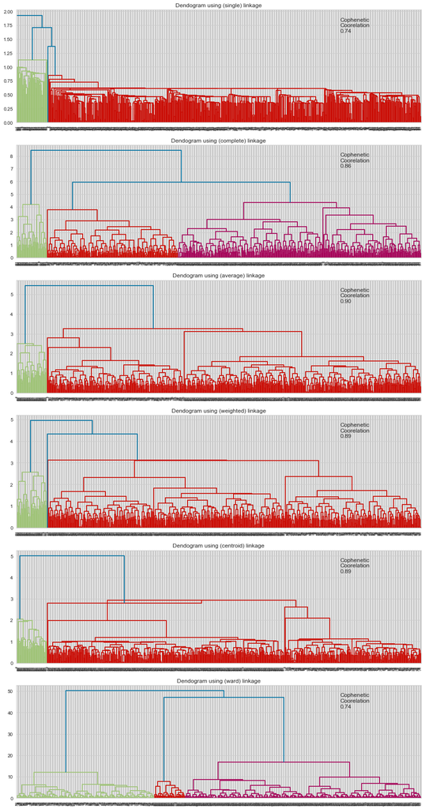

```python
# Plotting the dendogram for dataset.

fig, axs = plt.subplots(len(linkage_methods), 1, figsize=(15, 30))

for i, lin in enumerate(linkage_methods):
    Z = linkage(scaled_cls_data, method=lin, metric="euclidean")
    dendrogram(Z, ax=axs[i])
    coph_corr, coph_dist = cophenet(Z, pdist(scaled_cls_data))
    axs[i].set_title(f"Dendogram using ({lin}) linkage")
    axs[i].annotate(
        f"Cophenetic\nCoorelation\n{coph_corr:0.2f}",
        (0.80, 0.80),
        xycoords="axes fraction",
    )
```

**Observations**

- The cophenetic correlation is highest for average linkage has highest score.
- 5 seems to be appropriate number of clusters from the dendrogram.

```python
hcModel = AgglomerativeClustering(n_clusters=5, affinity="euclidean", linkage="average")
hcModel.fit(scaled_cls_data)
```

```
AgglomerativeClustering(linkage='average', n_clusters=5)
```

```python
scaled_cls_data["HC_Clusters"] = hcModel.labels_
data["HC_Clusters"] = hcModel.labels_
```

## Cluster Profiling

```python
hc_cls_profile = data.groupby("HC_Clusters").mean()
```

```python
hc_cls_profile.head(n=10)
```

| HC_Clusters | Customer_Key | Avg_Credit_Limit | Total_Credit_Cards | Total_visits_bank | Total_visits_online | Total_calls_made |
| --- | --- | --- | --- | --- | --- | --- |
| 0 | 56708.760000 | 141040.000000 | 8.740000 | 0.600000 | 10.900000 | 1.080000 |
| 1 | 55239.423423 | 12027.027027 | 2.400901 | 0.932432 | 3.531532 | 6.873874 |
| 2 | 54842.683938 | 33541.450777 | 5.520725 | 3.492228 | 0.984456 | 2.010363 |
| 3 | 87073.000000 | 100000.000000 | 2.000000 | 1.000000 | 1.000000 | 0.000000 |
| 4 | 38414.000000 | 50000.000000 | 3.000000 | 0.000000 | 10.000000 | 9.000000 |

```python
hc_cls_profile["count_in_each_segment"] = (
    data.groupby("HC_Clusters")["Customer_Key"].count().values
)
```

```python
# Get the customers for each cluster
def cluster_count(df):
    """
    Method to get the number of customers for each cluster for a given dataset
    """
    for cl in df["HC_Clusters"].unique():
        cust = df[df["HC_Clusters"] == cl]["Customer_Key"]
        print("Cluster {0} has {1} customers. These are".format(cl, cust.nunique()))
        print(cust.unique())
        print("-" * 100)
        print()


cluster_count(data)
```

```
Cluster 3 has 1 customers. These are
[87073]
----------------------------------------------------------------------------------------------------

Cluster 4 has 1 customers. These are
[38414]
----------------------------------------------------------------------------------------------------

Cluster 2 has 384 customers. These are
[17341 40496 54838 35254 46635 97825 83125 35483 15129 83290 56486 31903
 45909 14263 46813 81878 35549 85799 39122 81531 69965 18595 44398 32352
 40898 27101 33457 45088 23302 27408 65372 21531 56843 17165 89328 20072
 71402 47496 24808 17036 67193 34423 97109 55382 51811 53936 66504 53207
 18514 51319 36340 36934 95925 49771 22919 21233 74544 52025 45652 73952
 49418 77026 49331 75775 54906 94666 11698 34677 95610 41380 38033 85337
```

[output cut: 57 more lines]

**We'll try Ward linkage as it has more distinct and separated clusters as per dendrogram with 4 cluster as target.**

```python
hc_ward_Model = AgglomerativeClustering(
    n_clusters=4, affinity="euclidean", linkage="ward"
)
hc_ward_Model.fit(scaled_cls_data)
```

```
AgglomerativeClustering(n_clusters=4)
```

```python
scaled_cls_data["HC_Clusters"] = hc_ward_Model.labels_
data["HC_Clusters"] = hc_ward_Model.labels_
```

## Cluster Profiling

```python
hc_ward_profile = data.groupby("HC_Clusters").mean()
```

```python
hc_ward_profile["count_in_each_segments"] = (
    data.groupby("HC_Clusters")["Customer_Key"].count().values
)
```

```python
cluster_count(data)
```

```
Cluster 1 has 196 customers. These are
[87073 17341 40496 54838 35254 97825 35483 45909 14263 46813 35549 39122
 81531 18595 40898 27101 45088 65372 56843 20072 47496 53936 66504 51319
 21233 74544 45652 77026 49331 54906 94666 11698 34677 57565 31384 16374
 91987 51552 72156 24998 45673 81863 23881 44645 17933 47437 85614 96548
 19137 69028 67046 64897 36628 17565 11799 81940 66706 87838 47866 61996
 15318 89635 71862 82376 80347 17649 44579 61994 24702 27824 45878 72431
 19215 85122 55060 31113 68439 88207 96929 78618 31551 29864 45440 97954
 90189 55090 88884 45808 53932 65908 25321 48602 48657 49913 53002 82807
 93496 37252 41287 52460 58019 87219 36839 12663 48667 42887 14439 81166
 14816 11265 84351 89446 64774 53166 45341 36504 15798 84360 46776 67258
 44804 29919 74446 36632 76024 75065 51682 56367 95147 23102 49690 20043
 53552 62530 41741 61216 83192 82023 64550 17382 27117 21717 81910 76492
 43000 48692 43034 13140 91242 63710 90860 58708 57451 43679 26334 47848
 17377 51771 83585 68040 34775 85645 44157 75398 33295 80942 97850 59316
```

[output cut: 53 more lines]

**Now the clusters seem to have more balanced and variability.**

```python
# lets display cluster profile
hc_ward_profile.style.highlight_max(color="lightgreen", axis=0)
```

| HC_Clusters | Customer_Key | Avg_Credit_Limit | Total_Credit_Cards | Total_visits_bank | Total_visits_online | Total_calls_made | count_in_each_segments |
| --- | --- | --- | --- | --- | --- | --- | --- |
| 0 | 55163.973094 | 12197.309417 | 2.403587 | 0.928251 | 3.560538 | 6.883408 | 223 |
| 1 | 54291.525510 | 37520.408163 | 5.642857 | 2.525510 | 0.974490 | 2.142857 | 196 |
| 2 | 56708.760000 | 141040.000000 | 8.740000 | 0.600000 | 10.900000 | 1.080000 | 50 |
| 3 | 55577.015707 | 29806.282723 | 5.376963 | 4.471204 | 0.994764 | 1.863874 | 191 |

- Cluster 0 customers are most number of total calls made.
- Cluster 2 customers are most average credit limit, total_credit_Cards and Total_Visits_Online.
- Cluster 3 maximum number of bank visits.

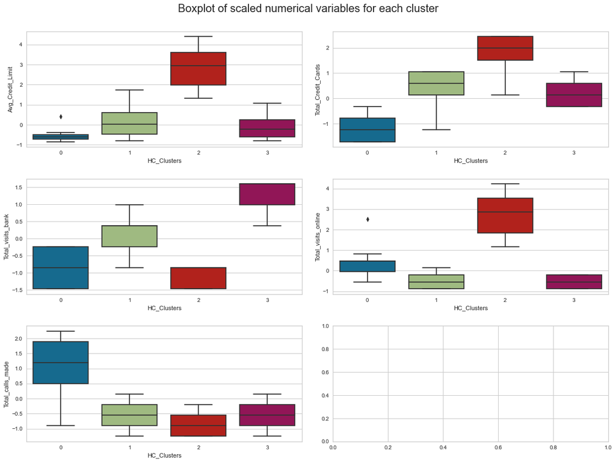

```python
# Box plot given dataset.
def cluster_box_plotfig(df, row, col, type):
    """
    Boxplot given dataset in given row and column formation
    """
    fig, axes = plt.subplots(row, col, figsize=(16, 12))
    fig.suptitle(
        "Boxplot of {0} numerical variables for each cluster".format(type),
        fontsize=20,
    )
    counter = 1
    for ii in range(row):
        if counter <= len(num_cols) - 1:
            sns.boxplot(
                ax=axes[ii][0],
                y=df[num_cols[counter]],
                x=df["HC_Clusters"],
            )
        counter = counter + 1
        if counter <= len(num_cols) - 1:
            sns.boxplot(
                ax=axes[ii][1],
                y=df[num_cols[counter]],
                x=df["HC_Clusters"],
            )
        counter = counter + 1

    fig.tight_layout(pad=2.0)


cluster_box_plotfig(scaled_cls_data, 3, 2, "scaled")
```

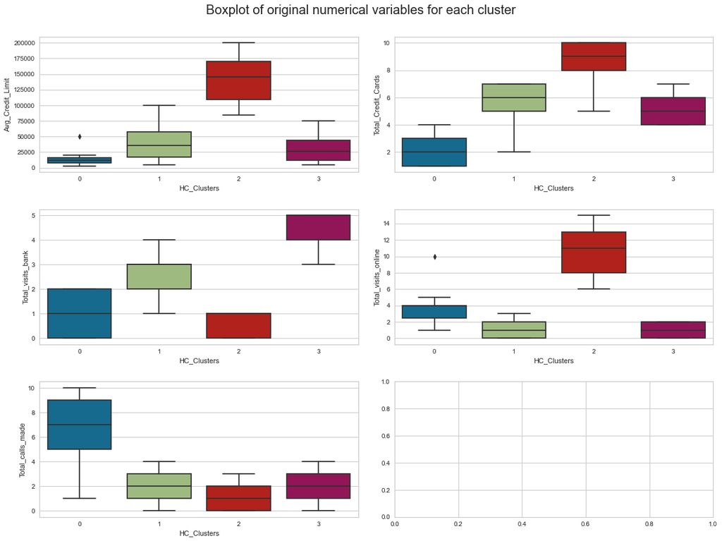

```python
cluster_box_plotfig(data, 3, 2, "original")
```

There is no difference in distribution of data on scaled and original.

## Insights

- **Cluster 0**:
  - Average credit has median value of 10000. Which is lowest among all.
  - Total credit card per customer is between 1-4. Which is lowest among all.
  - Total bank visits is between 0-2.
  - Total online visit is 1-4.
  - Total calls made is between 1-10. Which is highest among all.
- **Cluster 1**:
  - Average credit has median value of 35000.
  - Total credit card per customer is between 2-7.
  - Total bank visits is between 1-4.
  - Total online visit is 0-3.
  - Total calls made is between 0-4.
- **Cluster 2**:
  - Average credit has median value of 145000. Which is highest among all.
  - Total credit card median value is 9. Which is highest among all.
  - Total bank visits is between 0-1. Which is lowest among all.
  - Total online visit is 6-15. Which is highest among all.
  - Total calls made is between 0-3. Which is lowest among all.
- **Cluster 3**:
  - Average credit has median value of 25000.
  - Total credit card per customer is between 4-7.
  - Total bank visits is between 3 to 5. Which is highest among all.
  - Total online visit is between 0-2. Which is lowest among all.
  - Total calls made is between 0-4.

## Business Recommendations Based on Hierarchical Clustering

- **Cluster 0**: This cluster customers has lowest credit limit, lowest number of credit cards and lower number of bank visits , they are visiting bank portal online more than cluster 1 and cluster 3 But making most calls to customer care.Possibly, these customers belongs to lower income group or they have just started new job or they are living far off places from any bank branch.

  **Bank can offer family credit card for whole family tied to principal applicant. Offer online training for customer/whole family to show different credit card product to choose as per need or as per each family member need. Easy step to increase credit limit. To reduce number of calls bank can also train train them to use mobile app and virtual chat features**
- **Cluster 1** and **Cluster 3**: These customers maintain more number good number of credit cards but with lower limits. They also have highest number of bank visits that means they wanted to continue their relationship with bank.In additon they are not that much tech savvy. They are making moderate number number of calls to bank.

  **Bank can approach and organize training for online access of bank application to reduce their bank visits.This will lower the cost for bank per customer. Also understand their reason for visit and offer them to increase their credit limit after completion of training program, make them aware of features for different credit cards**
- **Cluster 2** : These customers can be considered premium customers. They are well informed, tech savvy and well aquainted with bank rules and product features making less number of calls to bank. Therefore, cost to maintain such customers is less.

  **They can be targeted for online campaign to promote new credit card with additional perks for being good customer, They can be offered easy step to increase existing credit limit or targeted first whenever bank is launching any new credit card product**

## Cluster Comparison and Additional Details

- K-Means clustering took less time to execute than Hierarchical Clustering because it spend more time in generating dendrograms.
- However, Hierarchical Clustering gave clear visualization through dendrograms to decide right number of clusters.
- Silhouette score details are mentioned plot wise for each cluster. it addition to that , it was highest for cluster 3(score: 0.52), then it went down sharply until cluster 5(0.27) and then started flattening after it .
- Observation in similar cluster of both algorithms

  `K_means_segments: 190, 221, 199, 50` `HC_Clusters : 196,223, 191, 50`

  For most of the clusters observations are differing slightly for extremely large data set this will be negligible difference. For one of the cluster observation is exactly matching.
- In both the case, K-Means clustering and Hierarchical Clustering appropriate number of clusters is 4. We can conclusively say that they are generating similar cluster. Therefore, insight and recommendation are almost same.
- These insight and recommendation are based on limited data and limited number of feature. It may differ if we have too many features and records.